# Practical G: Solutions

Linear Model

Maarten Cruyff

```r
library(MASS)
library(ggplot2)
library(dplyr)
library(gridExtra)
```

# 1 Animals

In this exercise you will work with the `Animals` data from the package `MASS`. These data include two variables measuring the brain and body weight of various animals. The central question in this exercise is: “Can we predict the weight of an animal’s brain from the weight of the animal’s body? The exercise shows that with some simple data transformations and adding a predictor we can go from 0% variance explained to almost 100%!

## 1.1 Linear model

1. Check the help file for `Animals`, and display the row names to get an idea of what kinds of animals are in the data.

```r
rownames(Animals)
```

```
##  [1] "Mountain beaver"  "Cow"              "Grey wolf"        "Goat"
##  [5] "Guinea pig"       "Dipliodocus"      "Asian elephant"   "Donkey"
##  [9] "Horse"            "Potar monkey"     "Cat"              "Giraffe"
## [13] "Gorilla"          "Human"            "African elephant" "Triceratops"
## [17] "Rhesus monkey"    "Kangaroo"         "Golden hamster"   "Mouse"
## [21] "Rabbit"           "Sheep"            "Jaguar"           "Chimpanzee"
## [25] "Rat"              "Brachiosaurus"    "Mole"             "Pig"
```

2. Let’s start with with some data visualizations. Display the boxplots showing the distributions of `brain` and `body`.

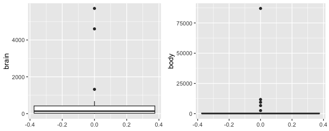

```r
grid.arrange(
  ggplot(Animals) +
    geom_boxplot(aes(y = brain)),
  ggplot(Animals) +
    geom_boxplot(aes(y = body)),
  nrow = 1)
```

3. Display a scatter plot with `body` on the x-axis and `brain` on the y-axis, and add a linear regression line including the confidence band. Interpret the plot.

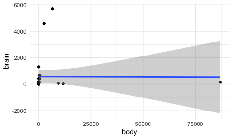

```r
ggplot(Animals, aes(x = body, y = brain)) +
  geom_point() +
  geom_smooth(method = "lm") +
  theme_minimal()
```

4. Let’s see how the linear regression model performs. Fit the linear model $m_0$ predicting `brain` from `body`; display its summary, and interpret the parameter estimates and the R-squared.

```r
m0 <- lm(formula = brain ~ body, data = Animals)
summary(m0)
```

```
##
## Call:
## lm(formula = brain ~ body, data = Animals)
##
## Residuals:
##    Min     1Q Median     3Q    Max
## -576.0 -554.1 -438.1 -156.3 5138.5
##
## Coefficients:
##               Estimate Std. Error t value Pr(>|t|)
## (Intercept)  5.764e+02  2.659e+02   2.168   0.0395 *
## body        -4.326e-04  1.589e-02  -0.027   0.9785
## ---
## Signif. codes:  0 '***' 0.001 '**' 0.01 '*' 0.05 '.' 0.1 ' ' 1
##
## Residual standard error: 1360 on 26 degrees of freedom
## Multiple R-squared:  2.853e-05,  Adjusted R-squared:  -0.03843
## F-statistic: 0.0007417 on 1 and 26 DF,  p-value: 0.9785
```

5. Display the diagnostic residual plots for the previous model, and interpret the results.

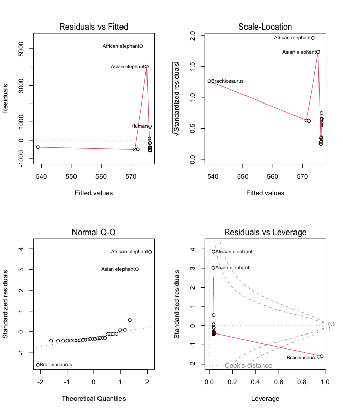

```r
par(mfcol = c(2, 2))
plot(m0)
```

## 1.2 Data transformations

Since the variables `brain` and `body` are substantially skewed, a data transformation may improve the fit of the model.

1. Apply transformations to normalize the distributions of the variables `body` and `brain`, and check the result with boxplots.

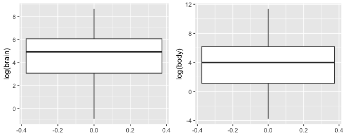

```r
grid.arrange(
  ggplot(Animals) +
    geom_boxplot(aes(y = log(brain))),
  ggplot(Animals) +
     geom_boxplot(aes(y = log(body))),
    nrow = 1)
```

2. Display a scatter plot of the transformed versions of `brain` and `body`, and add a linear regression line.

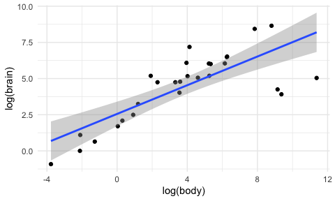

```r
ggplot(Animals, aes(x = log(body), y = log(brain))) +
  geom_point() +
  geom_smooth(method = "lm") +
  theme_minimal()
```

4. Fit the linear model `m1` with the transformed `body` predicting the transformed `brain`; display its summary, and interpret the parameter estimates and the R-squared.

```r
m1 <- lm(formula = log(brain) ~ log(body), data = Animals)
summary(m1)
```

```
##
## Call:
## lm(formula = log(brain) ~ log(body), data = Animals)
##
## Residuals:
##     Min      1Q  Median      3Q     Max
## -3.2890 -0.6763  0.3316  0.8646  2.5835
##
## Coefficients:
##             Estimate Std. Error t value Pr(>|t|)
## (Intercept)  2.55490    0.41314   6.184 1.53e-06 ***
## log(body)    0.49599    0.07817   6.345 1.02e-06 ***
## ---
## Signif. codes:  0 '***' 0.001 '**' 0.01 '*' 0.05 '.' 0.1 ' ' 1
##
## Residual standard error: 1.532 on 26 degrees of freedom
## Multiple R-squared:  0.6076, Adjusted R-squared:  0.5925
## F-statistic: 40.26 on 1 and 26 DF,  p-value: 1.017e-06
```

5. Display the diagnostic plots for `m1` and interpret. Are the model assumptions fulfilled?

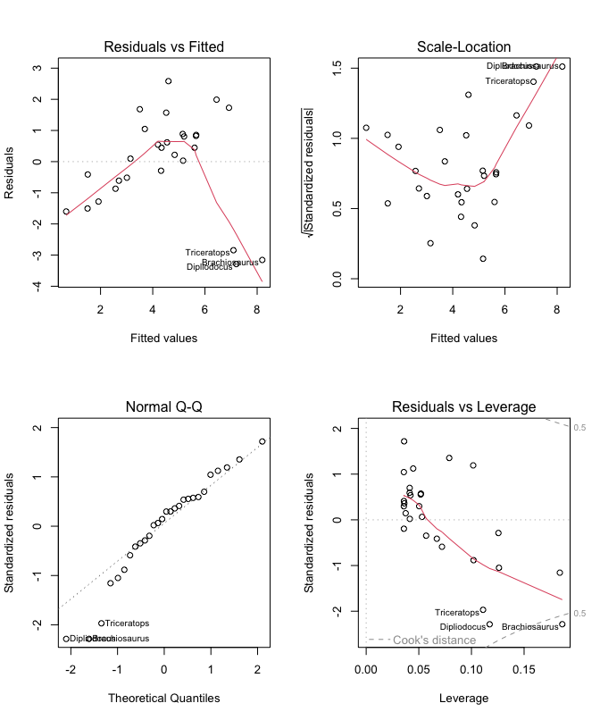

```r
par(mfcol = c(2, 2))
plot(lm(formula = log(brain) ~ log(body), data = Animals))
```

## 1.3 Adding a predictor

Additional predictors can help to satisfy the assumptions. For the data at hand, the residuals plots show three outliers that have one thing at common; they are prehistoric species. Let’s see what happens if we add a predictor to the model that distinguishes between extinct and other species.

1. Make the factor `species` with levels “extinct” for the prehistoric animals and “other” for the others, and add this factor to the data frame `Animals`.

```r
Animals <- mutate(Animals,
                  species = recode_factor(rownames(Animals),
                                          Brachiosaurus = "extinct",
                                          Triceratops   = "extinct",
                                          Dipliodocus   = "extinct",
                                          .default      = "other")
                  )
```

**OR**

```r
Animals <- mutate(Animals,
                  species = case_when(
                    rownames(Animals) %in% c("Brachiosaurus",
                                             "Triceratops",
                                             "Dipliodocus") ~ "extinct",
                    TRUE ~ "other")
                  )
```

2. Fit the model `m2` by adding the predictor `species` to model `m1`, display its summary, and interpret the parameter estimates and the R-squared.

```r
m2 <- lm(formula = log(brain) ~ log(body) + species, data = Animals)
summary(m2)
```

```
##
## Call:
## lm(formula = log(brain) ~ log(body) + species, data = Animals)
##
## Residuals:
##     Min      1Q  Median      3Q     Max
## -0.9042 -0.4335 -0.1240  0.2410  1.9344
##
## Coefficients:
##              Estimate Std. Error t value Pr(>|t|)
## (Intercept)  -3.05771    0.60118  -5.086 2.98e-05 ***
## log(body)     0.74855    0.04428  16.903 3.43e-15 ***
## speciesother  5.21935    0.53016   9.845 4.39e-10 ***
## ---
## Signif. codes:  0 '***' 0.001 '**' 0.01 '*' 0.05 '.' 0.1 ' ' 1
##
## Residual standard error: 0.7073 on 25 degrees of freedom
## Multiple R-squared:  0.9195, Adjusted R-squared:  0.9131
## F-statistic: 142.9 on 2 and 25 DF,  p-value: 2.088e-14
```

3. Display and interpret the diagnostic plots for `m2`.

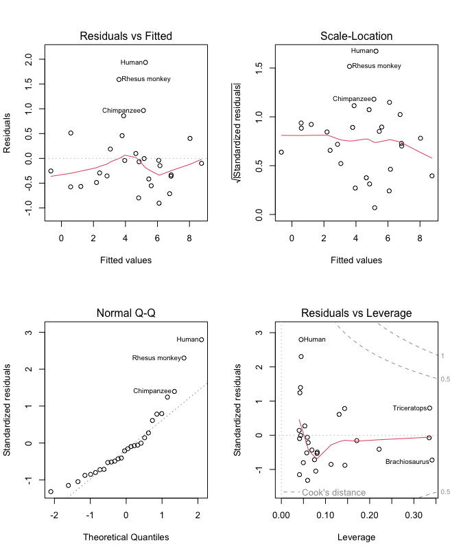

```r
par(mfcol = c(2, 2))
plot(m2)
```

The diagnostic plots show outliers that have a higher (logarithm of) `brain` than predicted by the model. These outliers belong to the class of species know as primates. This result suggests that the predictor `species` could be extended with the category `primates`.

4. Add the level “primate” to the variable `species` (check which of the animals are primates).

```r
Animals  <- mutate(Animals, species = recode_factor(rownames(Animals),
                                  'Brachiosaurus' = "extinct",
                                  'Triceratops'   = "extinct",
                                  'Dipliodocus'   = "extinct",
                                  'Human'         = "primate",
                                  'Chimpanzee'    = "primate",
                                  'Gorilla'       = "primate",
                                  'Rhesus monkey' = "primate",
                                  'Potar monkey'  = "primate",
                                  .default        = "other")
                   )
```

**OR**

```r
Animals <- mutate(Animals,
                  species = case_when(rownames(Animals) %in% c('Human',
                                                               'Chimpanzee',
                                                               'Gorilla',
                                                               'Rhesus monkey',
                                                               'Potar monkey') ~ "primate",
                                      TRUE ~ species)
                  )
```

5. Fit the model `m3` with the modified predictor `species`; display its summary, and interpret the parameter estimates and the R-squared.

```r
m3 <- lm(formula = log(brain) ~ log(body) + species, data = Animals)
summary(m3)
```

```
##
## Call:
## lm(formula = log(brain) ~ log(body) + species, data = Animals)
##
## Residuals:
##      Min       1Q   Median       3Q      Max
## -1.16459 -0.29307 -0.06216  0.29418  0.90147
##
## Coefficients:
##                Estimate Std. Error t value Pr(>|t|)
## (Intercept)     -2.9303     0.4148  -7.064 2.65e-07 ***
## log(body)        0.7358     0.0306  24.046  < 2e-16 ***
## speciesprimate   6.1776     0.4067  15.191 8.24e-14 ***
## speciesother     4.8689     0.3710  13.124 1.92e-12 ***
## ---
## Signif. codes:  0 '***' 0.001 '**' 0.01 '*' 0.05 '.' 0.1 ' ' 1
##
## Residual standard error: 0.4872 on 24 degrees of freedom
## Multiple R-squared:  0.9633, Adjusted R-squared:  0.9588
## F-statistic: 210.3 on 3 and 24 DF,  p-value: < 2.2e-16
```

6. Display and interpret the diagnostic plots for `m3`. What do the residual plots say about the brain weight of the Gorilla?

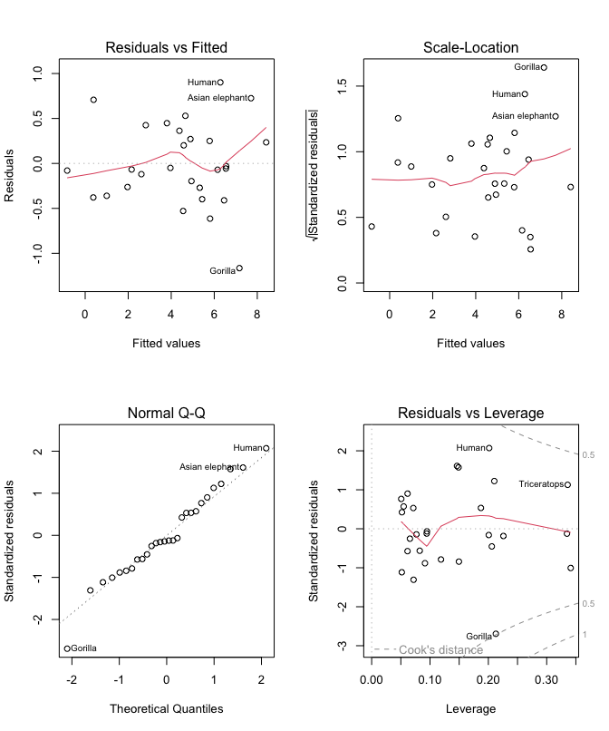

```r
par(mfcol = c(2, 2))
plot(m3)
```

7. Test the fit of the models `m1` to `m3` with the `anova()` function.

```r
anova(m1, m2, m3)
```

```
## Analysis of Variance Table
##
## Model 1: log(brain) ~ log(body)
## Model 2: log(brain) ~ log(body) + species
## Model 3: log(brain) ~ log(body) + species
##   Res.Df    RSS Df Sum of Sq       F    Pr(>F)
## 1     26 60.988
## 2     25 12.505  1    48.483 204.264 3.096e-13 ***
## 3     24  5.696  1     6.809  28.687 1.692e-05 ***
## ---
## Signif. codes:  0 '***' 0.001 '**' 0.01 '*' 0.05 '.' 0.1 ' ' 1
```

End of practical